# Visualização de Dados - ggplot

### Gráfico de Barras - `geom_bar()`

Ao se trabalhar com dados, sempre nos deparamos com dados relacionados à frequência. Tendemos a agrupar dados e, no agrupamento de dados, muitas vezes uma boa estatística descritiva é a frequência com a qual os dados ocorrem. Existem alguns tipos de gráficos que trabalham este tipo de dados. Porém, o mais utilizado por larga margem é o gráfico de barras.

O gráfico de barras é uma versão do histograma para dados discretos. Sua geração no `ggplot` ocorre por meio da geometria `geom_bar()`. Vamos fazer um gráfico de barras com a origem dos veículos.

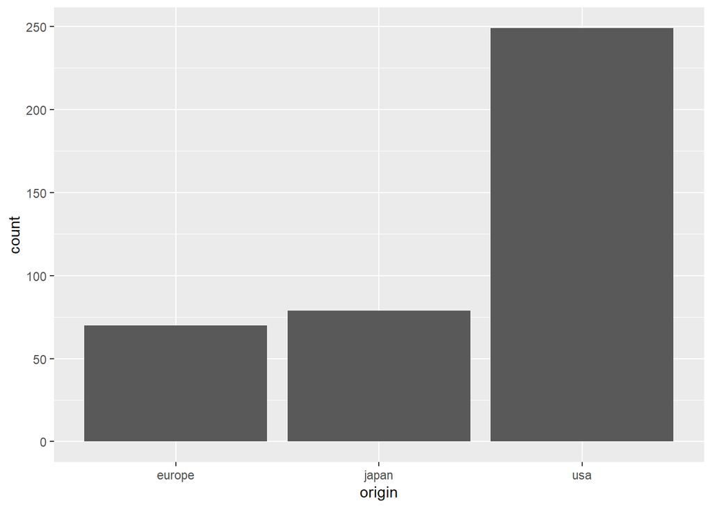

```r
#Gráfico de barras
car %>%
  ggplot(aes(origin)) +
  geom_bar()
```

Note que o gráfico foi gerado com as observações totais, ou seja, a própria função efetuou os cálculos de frequência. O gráfico de barras pode ser gerado para dados pré-sumarizados. Por exemplo, podemos gerar um gráfico de barras de uma tabela. Para tal, precisamos informar à geometria o tipo de sumarização utilizado. No caso de valores agregados, utilizamos o parâmetro `stat = 'identity'` dentro da geometria `geom_bar()`.

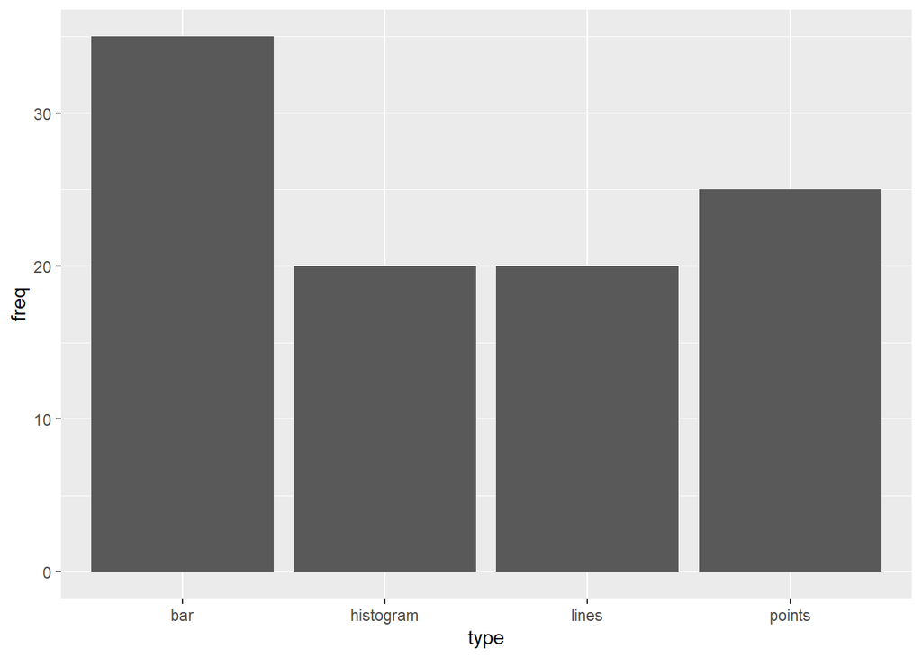

```r
#Vamos gerar uma tabela fictícia
graph <- data.frame(
  type = c("bar", "histogram", "lines", "points"),
  freq = c(35, 20, 20, 25)
)

#Agora gerar o gráfico de barras com a tabela criada
graph %>%
  ggplot(aes(type, freq)) +
  geom_bar(stat = "identity")
```

Muitas vezes é interessante apresentar os dados de forma ordenada, ou seja, apresentá-los de forma que seja visível o ordenamento de frequências. Não há um parâmetro dentro do pacote `ggplot` para realizar o ordenamento. Para tal, devemos utilizar a função `reorder` do pacote `stats` Vejamos como fazer o gráfico anterior de forma ordenada.

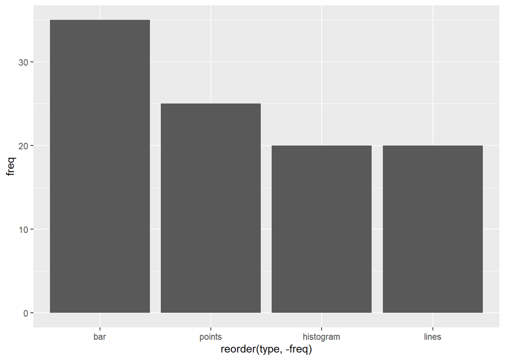

```r
#Gráfico ordenado em frequência decrescente
graph %>%
  ggplot(aes(reorder(type, -freq), freq)) +
  geom_bar(stat = "identity")
```

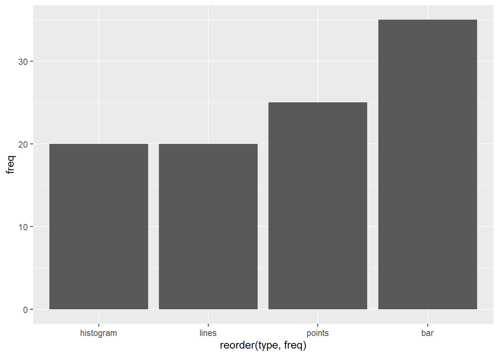

```r
#Gráfico ordenado em frequência crescente
graph %>%
  ggplot(aes(reorder(type, freq), freq)) +
  geom_bar(stat = "identity")
```

Algumas variações dos gráficos de barras são bastante importantes na visualização de dados. Por exemplo temos os gráficos de barras **agrupadas** e **empilhadas**. Gráficos de **barras agrupadas** tem como principal objetivo a comparação de frequências dentro os grupos, enquanto os gráficos de barras empilhadas, além de permitir a comparação de frequências dentro grupos, atendem ao objetivo de comparar as frequências entre os grupos. Ainda existe um terceiro formato, que são os gráficos de percentuais empilhados, para comparar as proporções de casos em cada grupo.

O agrupamento, empilhamento e empilhamento percentual são realizados por meio do parâmetro `position:`

- `position = "dodge"` para geração de barras agrupadas.
- `position = "stack"` para barras empilhadas.
- `position = "fill"` para barras empilhadas em percentual.

Em todos os casos, o parâmetro de agrupamento é informado na estética `fill`. Para tal, precisamos construir uma tabela que reflita aos dados que desejamos. Vamos construir a tabela dos dados e construir alguns gráficos:

```r
#Tabela de dados
data <- car %>%
  group_by(model_year, origin) %>%
  summarise(count = n()) %>%
  mutate(freq = count/sum(count))

data
```

```
# A tibble: 39 × 4
# Groups:   model_year [13]
   model_year origin count   freq
        <int> <chr>  <int>  <dbl>
 1         70 europe     5 0.172
 2         70 japan      2 0.0690
 3         70 usa       22 0.759
 4         71 europe     4 0.143
 5         71 japan      4 0.143
 6         71 usa       20 0.714
 7         72 europe     5 0.179
 8         72 japan      5 0.179
 9         72 usa       18 0.643
10         73 europe     7 0.175
# ℹ 29 more rows
```

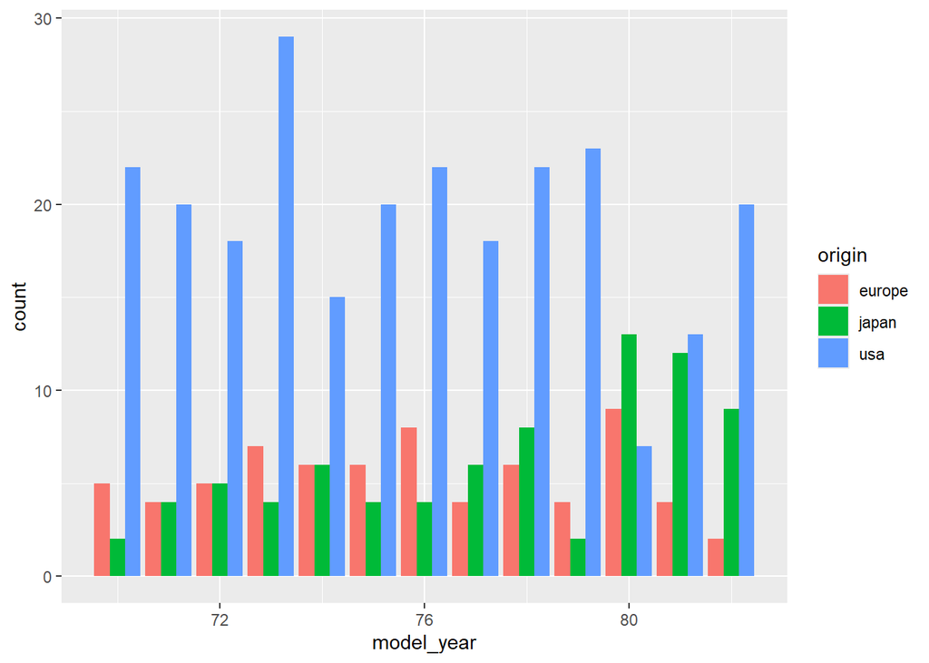

```r
#Gráfico de barras de ano de fabricação agrupados por origem
data %>%
  ggplot(aes(model_year, count, fill = origin)) +
  geom_bar(stat = 'identity', position = "dodge")
```

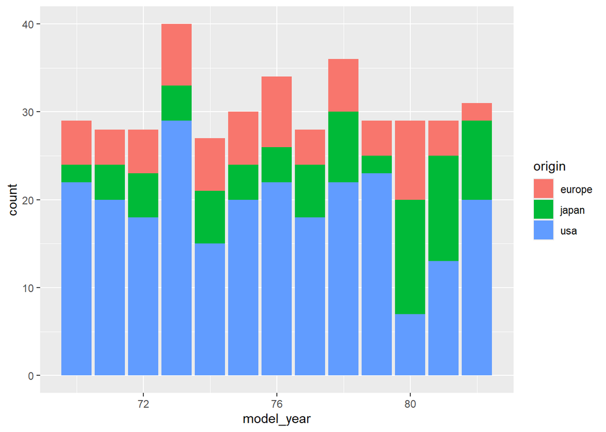

```r
#Gráfico de barras de ano de fabricação empilhados por origem
data %>%
  ggplot(aes(model_year, count, fill = origin)) +
  geom_bar(stat = 'identity', position = "stack")
```

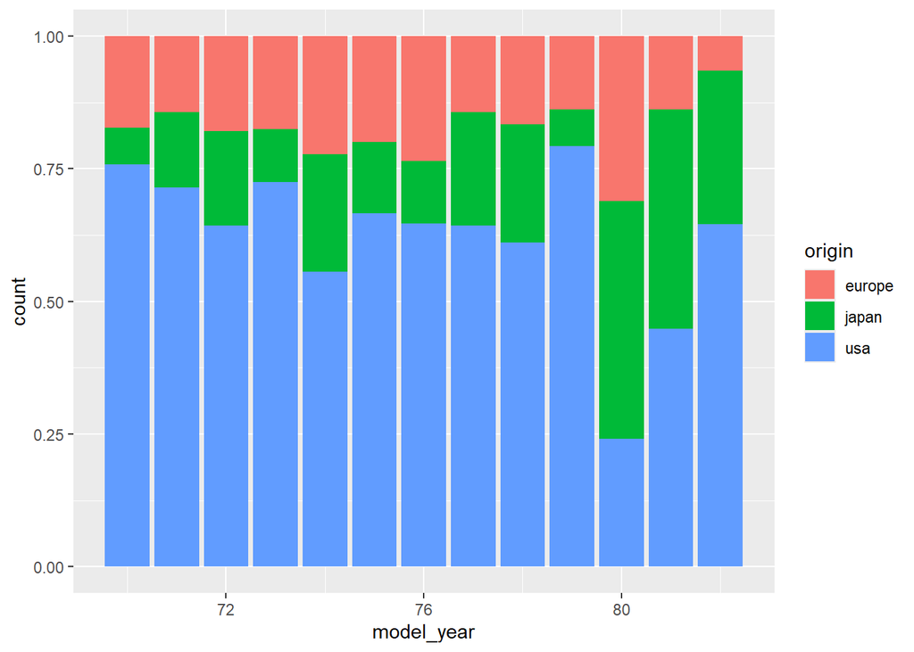

```r
#Gráfico de percentuais empilhados agrupados por origem
data %>%
  ggplot(aes(model_year, count, fill = origin)) +
  geom_bar(stat = 'identity', position = "fill")
```

Note que os dois primeiros gráficos utilizam as mesmas informações. Porém, no primeiro a possibilidade de comparação entre anos modelo é mais complexa. Já no segundo gráfico, além das proporções, é possível comparar os totais. Já no terceiro gráfico, os valores totais são suprimidos, restando apenas a composição proporcional da amostra.

Também é possível apresentar os gráficos na horizontal. Basta utilizar a camada `coord_flip` para construir o gráfico horizontalmente.

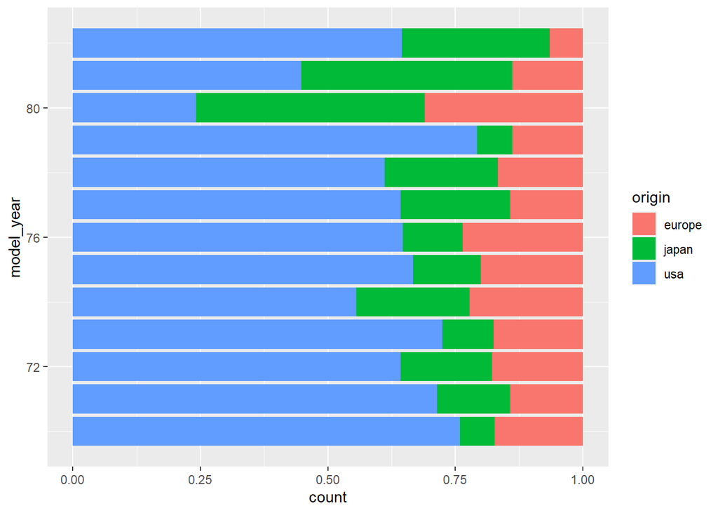

```r
#Girando o gráfico para a posição horizontal
data %>%
  ggplot(aes(model_year, count, fill = origin)) +
  geom_bar(stat = 'identity', position = "fill") +
  coord_flip()
```

O gráfico de barras e suas variações são capazes de resolver o problema de visualização para grande parte dos problemas de frequência. Vamos ver na sequência a plotagem de gráficos de linha e caminho.

### Gráficos de linhas e caminhos - `geom_line()` e `geom_path()`

Gráficos de linhas e caminhos usualmente são utilizados por dados que apresentam alguma forma de ordenamento. Alguns exemplos são séries temporais em geral, tais como temperaturas diárias, valorização de ativos, número de clientes por dia, dentre outros. Podemos por exemplo efetuar medidas com algum ordenamento geográfico. Por exemplo, ao se medir a contaminação de água por coliformes fecais em um rio, em diversos pontos, no sentido descendente, pode se utilizar o gráfico de caminhos para analisar como a contaminação oscila a cada ponto.

Como o conjunto de dados em estudo não apresenta nenhuma variável ordenada, utilizaremos o conjunto de dados `economics`, presente no próprio pacote `ggplot2`, que contém dados econômicos dos Estados Unidos.

Assim como nas demais geometrias, podemos controlar alguns parâmetros, como alterar a cor das linhas (parâmetro `colour`), espessura das linhas (parâmetro `size`), transparência da linha (parâmetro `alpha`), dentre outros. também podemos plotar séries simultâneamente usando o parâmetero `fill`. Vamos gerar alguns gráficos relacionados ao desemprego por data nos EUA.

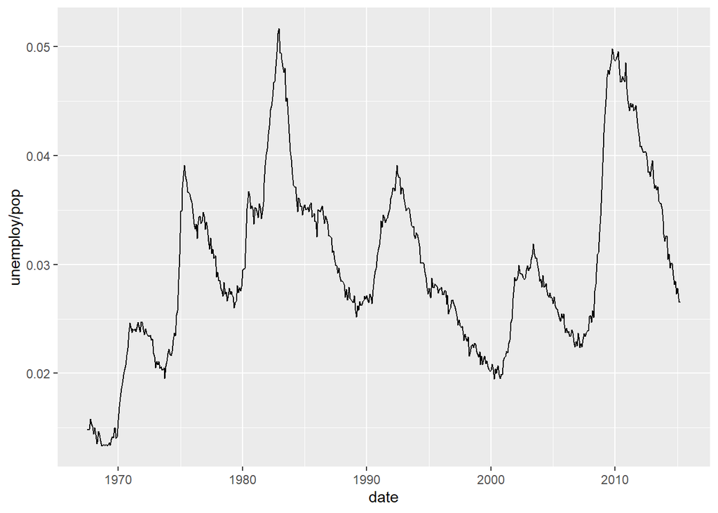

```r
#Gráfico de taxa de desemprego por população
economics %>%
  ggplot(aes(date, unemploy/pop)) +
  geom_line()
```

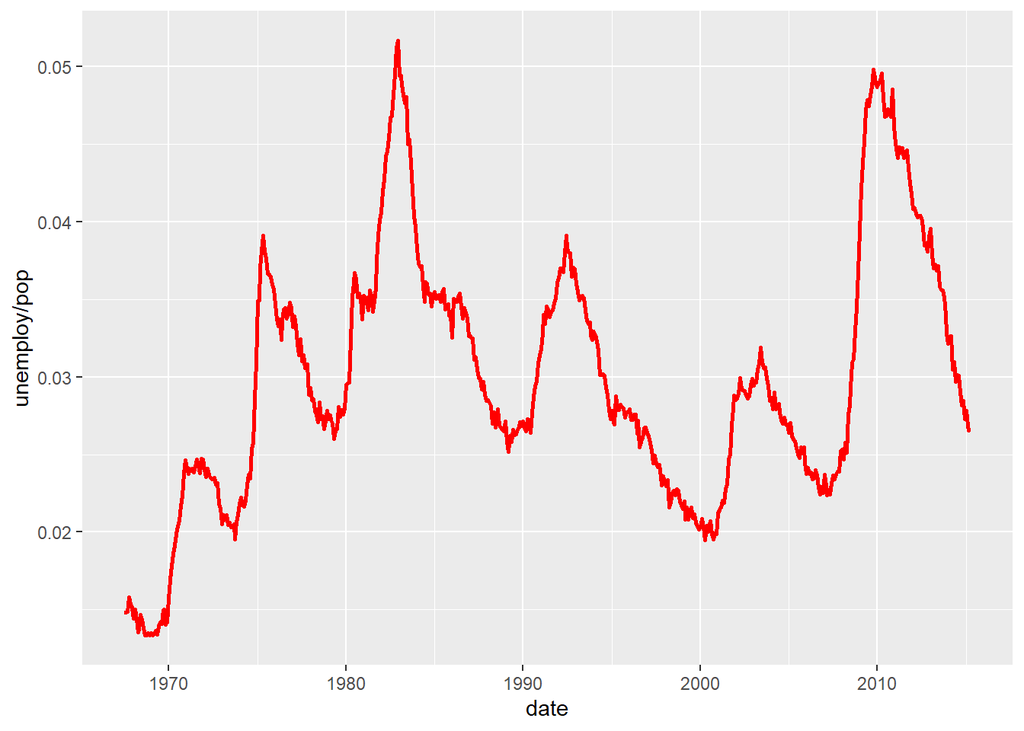

```r
#Alterando cor e espessura da linha
economics %>%
  ggplot(aes(date, unemploy/pop)) +
  geom_line(colour = "red", linewidth = 1)
```

Podemos também utilizar a geometria `geom_path()` para plotar o diagrama de caminhos. Vamos plotar o caminho percorrido pela taxa de desemprego e pelo número mediano de semanas desempregado, e posteriormente avaliar a evolução por ano.

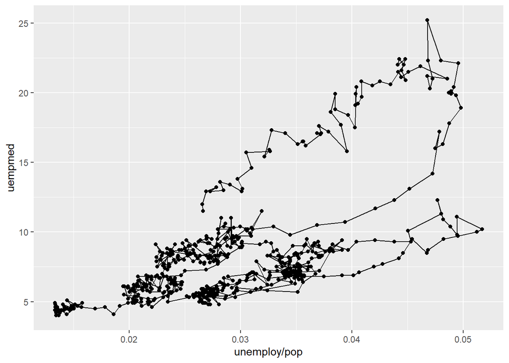

```r
#Gráfico de desempregados por número de semanas desempregado
economics %>%
  ggplot(aes(unemploy / pop, uempmed)) +
  geom_path() +
  geom_point()
```

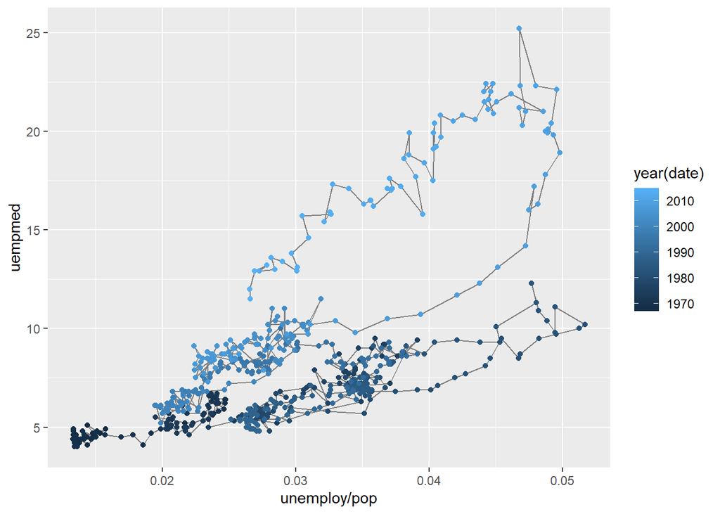

```r
#Gráfico de caminhos com gradação de ano
economics %>%
  ggplot(aes(unemploy / pop, uempmed)) +
  geom_path(colour = 'grey50') +
  geom_point(aes(colour = year(date)))
```

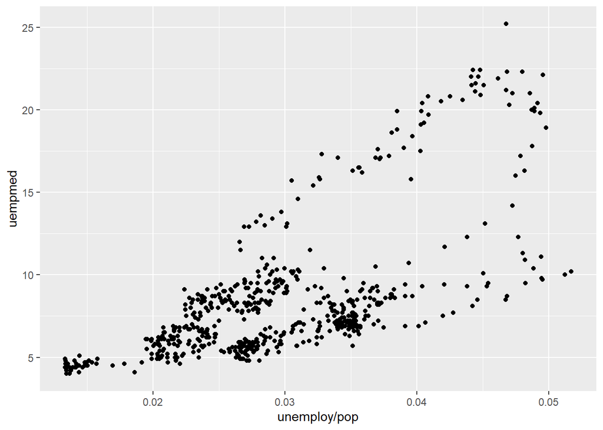

```r
#Compare agora com o gráfico sem ordenação
economics %>%
  ggplot(aes(unemploy / pop, uempmed)) +
  geom_point()
```

Com este gráfico é nítido que existe correlação entre as variáveis. Entretanto, ao se analisar o diagrama de caminhos, percebe-se que a taxa é decrescente nos últimos anos. Com estes gráficos, cobrimos os principais tipos de gráficos que trabalharemos em visualização. Vamos agora trabalhar alguns aspectos adicionais de manipulação dos gráficos.

## Outros elementos importantes

Para finalizar a apresentação dos principais aspectos do `ggplot`, vamos trabalhar alguns elementos de customização importantes para melhorar a qualidade dos gráficos: Eixos, anotações e temas.

### Modificando os eixos

Podemos modificar alguns aspectos dos eixos:

- Rótulos - Funções `xlab` e `ylab`;
- Escalas - Funções da família `scale`;
- Limites - Funções `xlim` e `ylim`;

Vamos modificar os eixos de alguns dos gráficos apresentados acima. Vamos utilizar o pacote ggpubr para organizar os gráficos com e sem modificações lado a lado

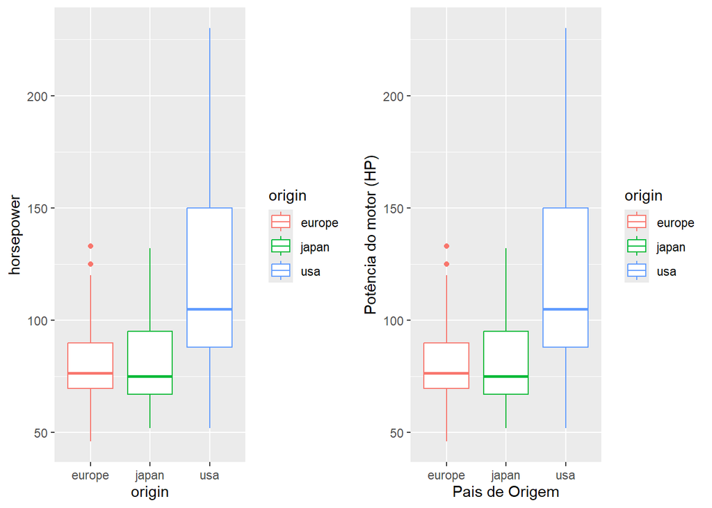

```r
library(ggpubr)

#Boxplot com eixos originais e alterados
g1 <- car %>%
  ggplot(aes(origin, horsepower, colour = origin)) +
  geom_boxplot()

g2 <- car %>%
  ggplot(aes(origin, horsepower, colour = origin)) +
  geom_boxplot() +
  xlab("Pais de Origem") +
  ylab("Potência do motor (HP)")

ggarrange(g1, g2, ncol = 2)
```

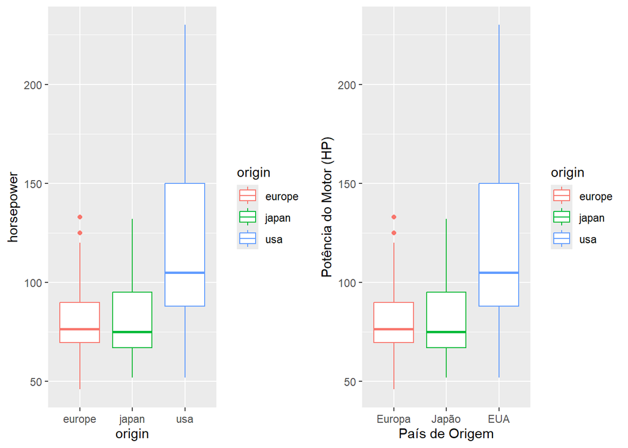

```r
#Boxplot simples com alteração na cor das linhas
g1 <- car %>%
  ggplot(aes(origin, horsepower, colour = origin)) +
  geom_boxplot()

g2 <- car %>%
  ggplot(aes(origin, horsepower, colour = origin)) +
  geom_boxplot() +
  scale_x_discrete(labels = c("Europa", "Japão", "EUA")) +
  xlab("País de Origem") +
  ylab("Potência do Motor (HP)")

ggarrange(g1, g2, ncol = 2)
```

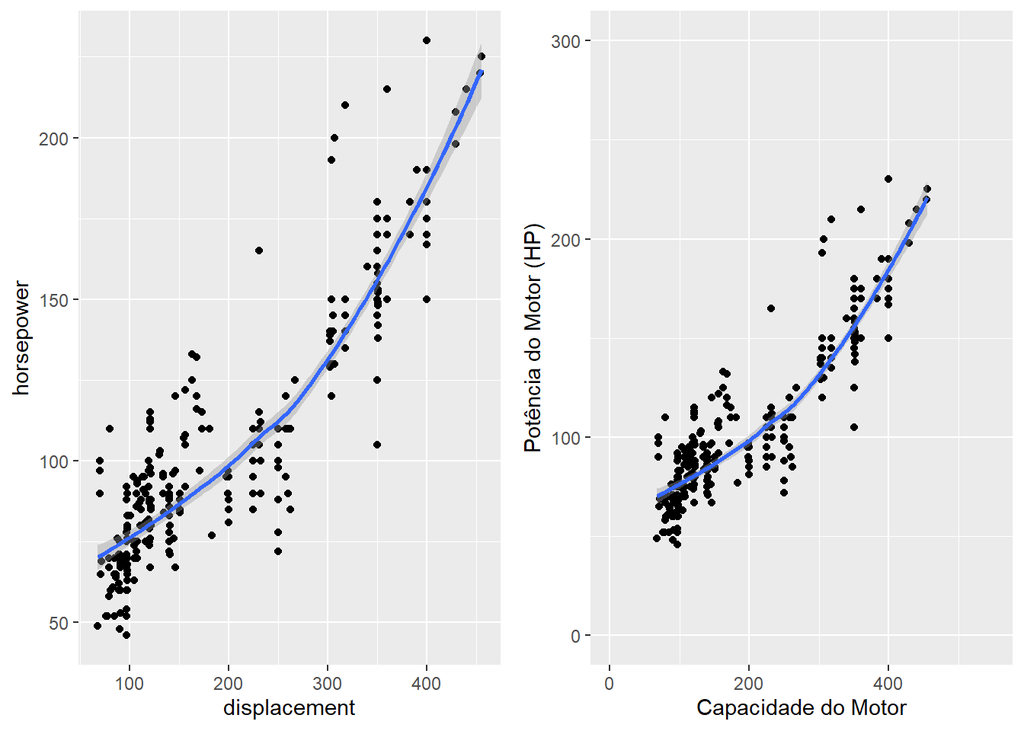

```r
#Tamanho do motor vs potência sem e com alterações
g1 <- car %>%
  ggplot(aes(x = displacement, y = horsepower)) +
  geom_point() +
  geom_smooth(span = 1)

g2 <- car %>%
  ggplot(aes(x = displacement, y = horsepower)) +
  geom_point() +
  geom_smooth(span = 1) +
  xlim(0, 550) +
  ylim(0, 300) +
  xlab("Capacidade do Motor") +
  ylab("Potência do Motor (HP)")

ggarrange(g1, g2, ncol = 2)
```

### Anotações

Quando estamos trabalhamos com gráficos, é corriqueira a necessidade de alterar elementos textuais, como legendas, eixos, como vimos na seção anterior, títulos, títulos das legendas, dentre outros. Muitos destes parâmetros conseguimos alterar diretamente na função `labs()`. Podemos inclusive repassar fórmulas, se necessário

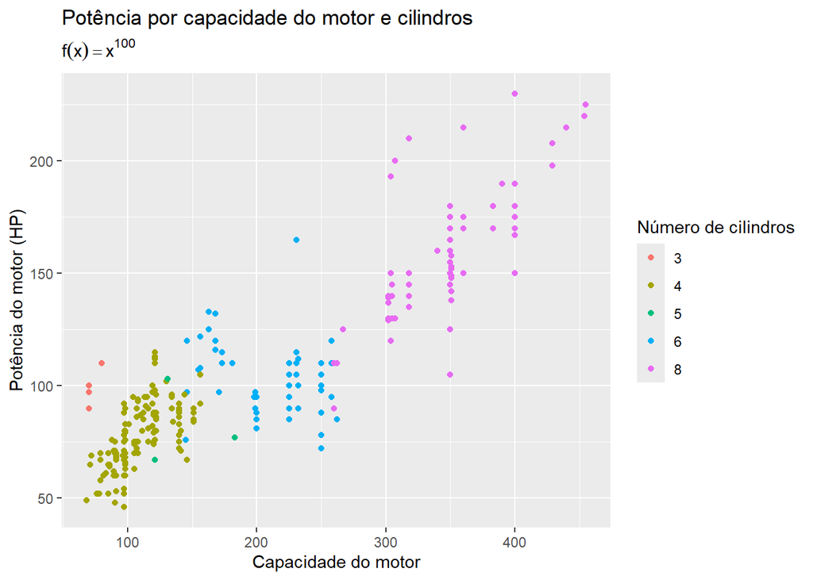

```r
#Gráfico de potência por capacidade do motor e cilindros
car %>%
  ggplot(aes(x = displacement, y = horsepower, colour = factor(cylinders))) +
  geom_point() +
  labs(x = "Capacidade do motor",
       y = "Potência do motor (HP)",
       colour = "Número de cilindros",
       title = "Potência por capacidade do motor e cilindros",
       subtitle = quote(f(x) == x^100))
```

Podemos também realizar a inclusão de texto nos gráficos por meio da geometria `geom_text()`. O tamanho da fonte é controlado pelo parâmetro size. Também podemos alterar outros parâmetros, como cor, transparência, tipo de fonte, ângulo, dentre outros

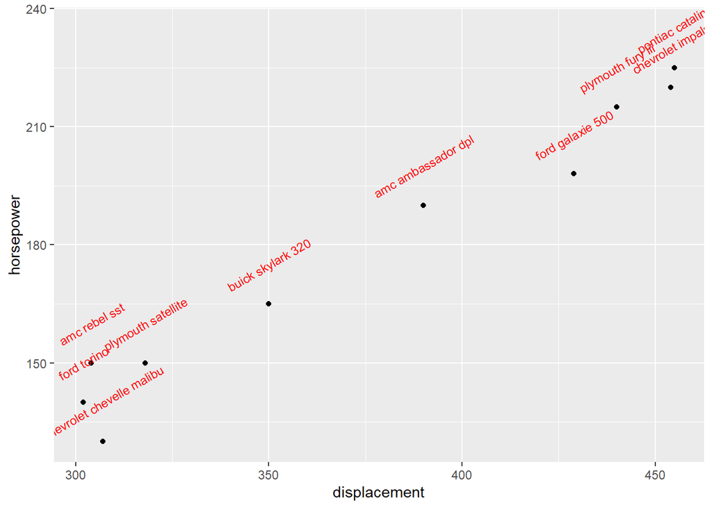

```r
#Plotando os rótulos dos carros
car[1:10,] %>%
  ggplot(aes(x = displacement, y = horsepower)) +
  geom_point() +
  geom_text(aes(label = name, y = horsepower + 10), size = 3, angle = 30, colour = 'red')
```

Vamos plotar as porcentagens nos gráficos de barras anteriores. Para incluí-la, vamos criar uma variável com os valores já em percentual. Para ajustá-los ao posicionamento das barras, devemos utilizar o parâmetro `position` dentro da função `geom_text`. Para que o posicionamento fique correto, devemos usar uma das seguintes funções , a depender do tipo de gráfico:

- Barras agrupadas: `position = position_dodge`
- Barras empilhadas: `position = position_stack(vjust = 0.5)`
- Barras empilhadas por percentual: `position = position_fill(vjust = 0.5)`

O parâmetro `vjust` controla o alinhamento do texto dentro das barras em relação à posição. `vjust = 0` alinha na base, `vjust = 0.5` alinha no centro, `vjust = 1` alinha no topo.

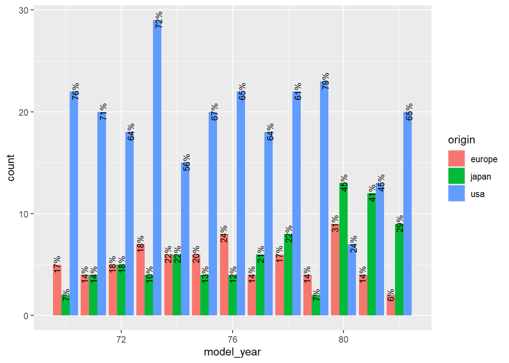

```r
#Adição dos percentuais
data <- data %>%
  mutate(percentual = paste0(round(100*count/sum(count),0),"%"))


#Gráfico de barras de ano de fabricação agrupados por origem
data %>%
  ggplot(aes(model_year, count, fill = origin)) +
  geom_bar(stat = 'identity', position = "dodge") +
  geom_text(aes(x = model_year, y = count,
                label = percentual),
            position = position_dodge(1),
            size = 3,
            angle = 90)
```

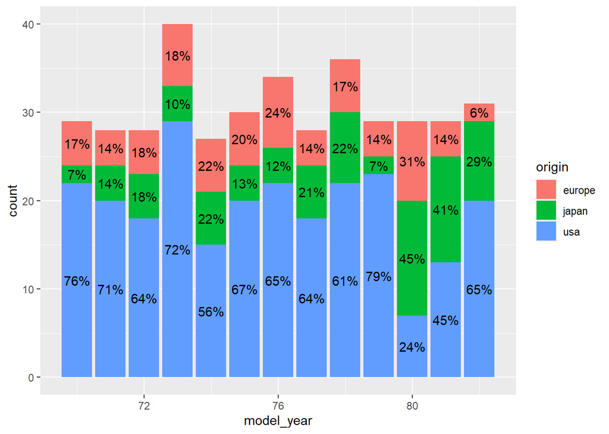

```r
#Gráfico de barras de ano de fabricação empilhados por origem
data %>%
  ggplot(aes(model_year, count, fill = origin)) +
  geom_bar(stat = 'identity', position = "stack") +
  geom_text(aes(x = model_year, y = count,
                label = percentual),
            position = position_stack(vjust = .5))
```

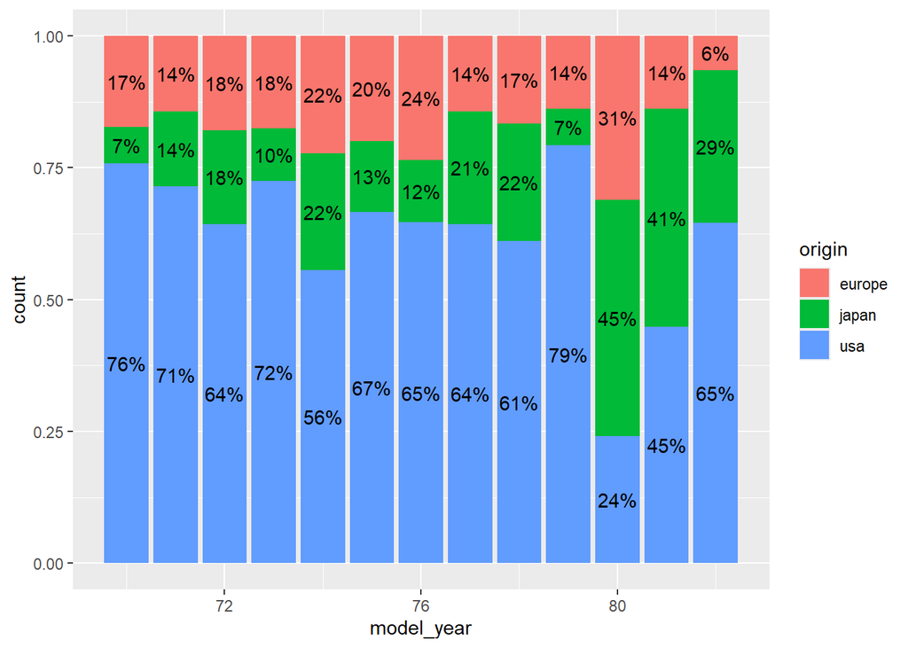

```r
#Gráfico de percentuais empilhados agrupados por origem
data %>%
  ggplot(aes(model_year, count, fill = origin)) +
  geom_bar(stat = 'identity', position = "fill") +
  geom_text(aes(x = model_year, y = count,
                label = percentual),
            position = position_fill(vjust = .5))
```

Além das opções apresentadas, existem diversas possibilidades de controle de texto. As necessidades em geral aparecem durante a análise.

### Temas

O pacote `ggplot` oferece alguns temas pré-definidos, além da possibilidade da inclusão de novos temas por meio de pacotes adicionais, como por exemplo o pacote `ggthemes`. Vejamos alguns temas

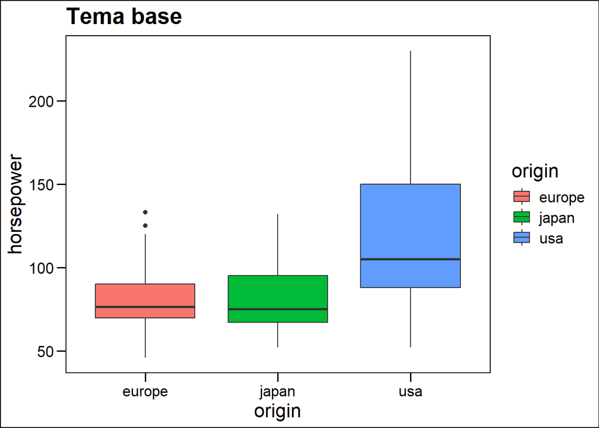

```r
library(ggthemes)

base <- car %>%
  ggplot(aes(origin, horsepower, fill = origin)) +
  geom_boxplot()


base + theme_base() + labs(title = "Tema base")
```

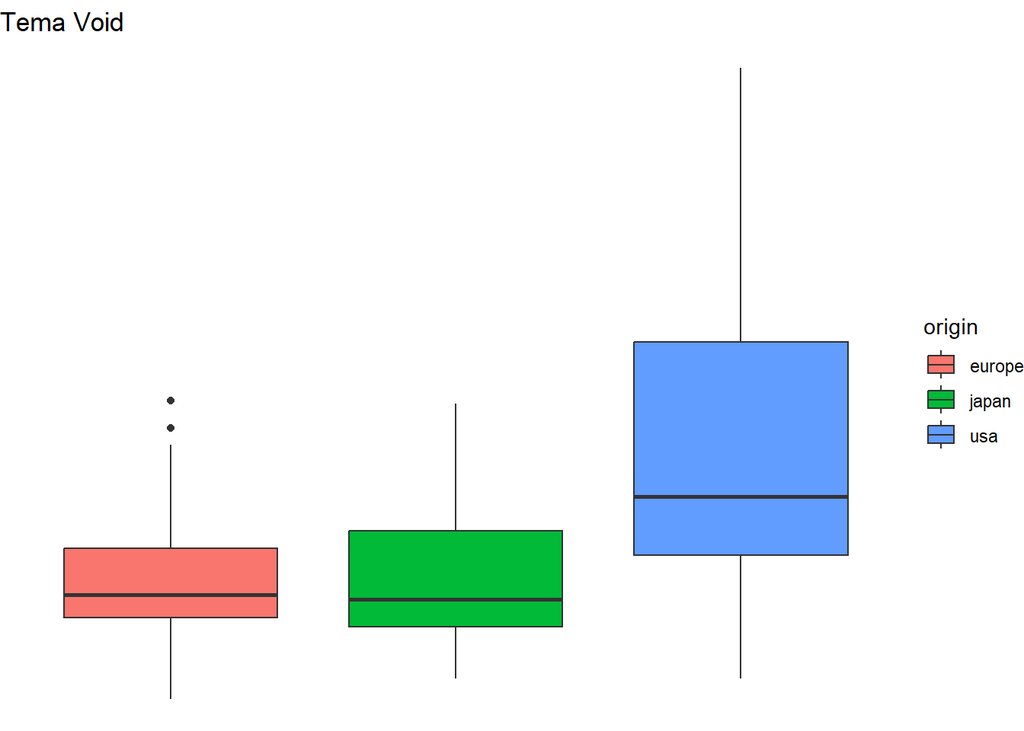

```r
base + theme_void() + labs(title = "Tema Void")
```

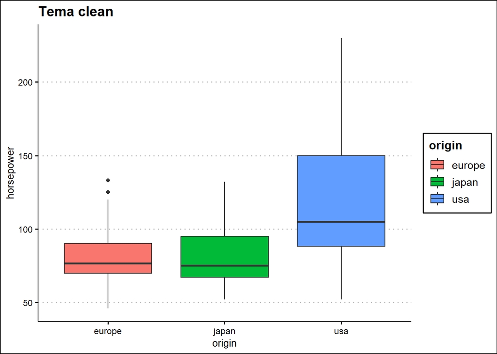

```r
base + theme_clean() + labs(title = "Tema clean")
```

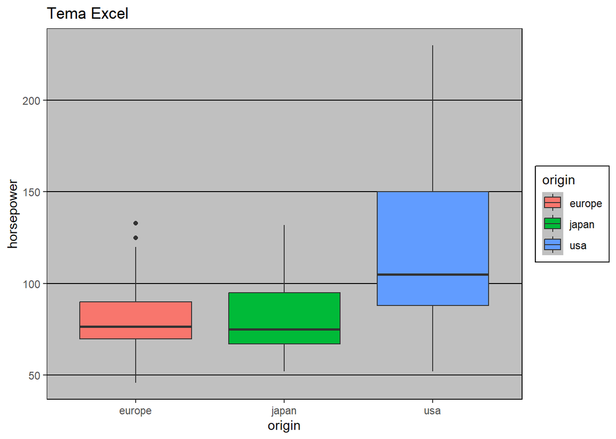

```r
base + theme_excel() + labs(title = "Tema Excel")
```

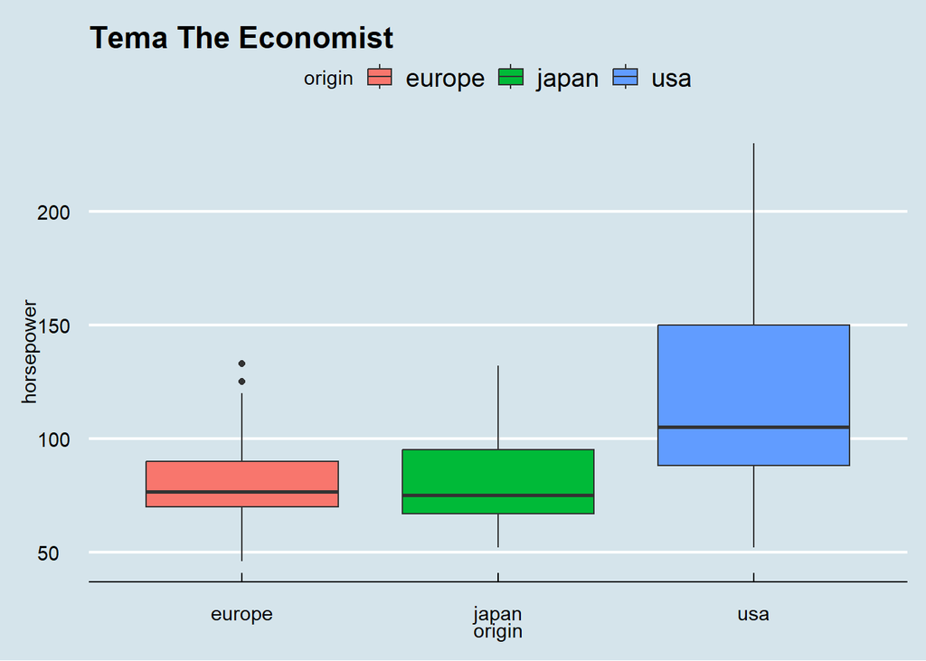

```r
base + theme_economist() + labs(title = "Tema The Economist")
```

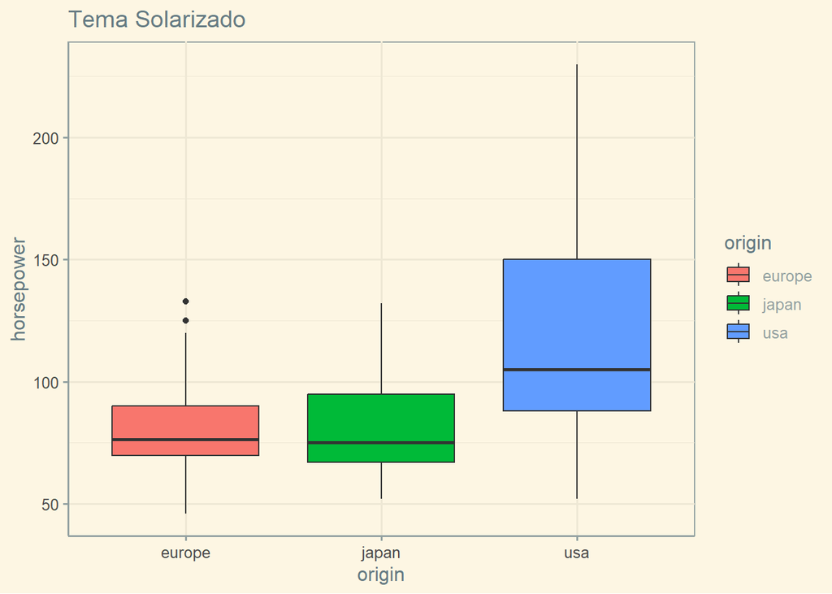

```r
base + theme_solarized() + labs(title = "Tema Solarizado")
```

Outros exemplos de temas podem ser visualizados no link https://yutannihilation.github.io/allYourFigureAreBelongToUs/ggthemes/

Qualquer tentativa de apresentar o pacote `ggplot` em sua totalidade será frustrada. O pacote apresenta opções praticamente ilimitadas de construção e customização de gráficos. Entretanto, esta introdução servirá como base para a expansão para outras funcionalidades, bem como outros pacotes, que continuaremos a explorar nas próximas seções.

## Exercícios

Utilize o banco de dados `dados_mostra.csv`, disponível no Moodle, para gerar os seguintes gráficos usando `ggplot`.

1. Evolução do número de visitas por hora;
2. Pessoas que ouviram e não ouviram falar do curso de Estatística.
3. Opiniões sobre o curso de Estatística após a apresentação.
4. Informações que mais chamaram a atenção dos visitantes
5. Cidade de origem.
6. Disponibilidade em receber e-mails por conhecimento prévio sobre o curso
7. Disponibilidade em receber e-mails por informações que mais chamaram atenção.

Algumas orientações:

- Corrija os títulos dos eixos e inclua os rótulos sempre que possível.
- Para gráficos semelhantes, varie elementos (cores, rotações, etc).
- Interprete os resultados obtidos.
- Respostas livres devem ser agrupadas como “Outras”.
- Lembre-se de realizar as transformações necessárias nos dados e utilizar os gráficos adequados para cada visualização.

## References

Wilkinson, Leland. 2012. *The Grammar of Graphics*. Springer.